# Relatório sobre as informações armazenadas na base IMDb entre 1969 e 2015

Insights sobre um bom investimento

##### Produzido por: Vitória Barbosa Ferreira

## Introdução

A base IMDb (Internet Movie Database) é uma base de dados que contém informações relacionadas a filmes, programas de televisão, streammings e video games. A página contém mais de 6.5 milhões de títulos com cerca de 83 mlhões de usuários cadastrados. Usuários da página podem avaliar o conteúdo do que assistem em uma escala de 1 a 10. A média ponderada dessas avaliações é convertida na nota IMDb do filme.

Como a IMDb é líder no seu setor, é possível afirmar que esta base de dados é confiável para avaliar a popularidade de um filme.

Além da nota IMDB a base analisada neste relatório contém informações sobre títulos de filmes, gêneros, classificação, duração, atores, diretores, orçamento, receita, ano de lançamento e quantidade de likes no facebook. Vale dizer que a base analisada consiste em uma amostra de filmes lançados que foram lançados entre 1969 e 2015.

O objetivo dessa análise é oferecer insights sobre possíveis bons investimentos com base nas informações desta amostra.

Filmes com notas IMDb maior ou igual a 8 serão considerados como filmes muito bem avaliados.

## Nota IMDb em relação ao orçamento e ao lucro

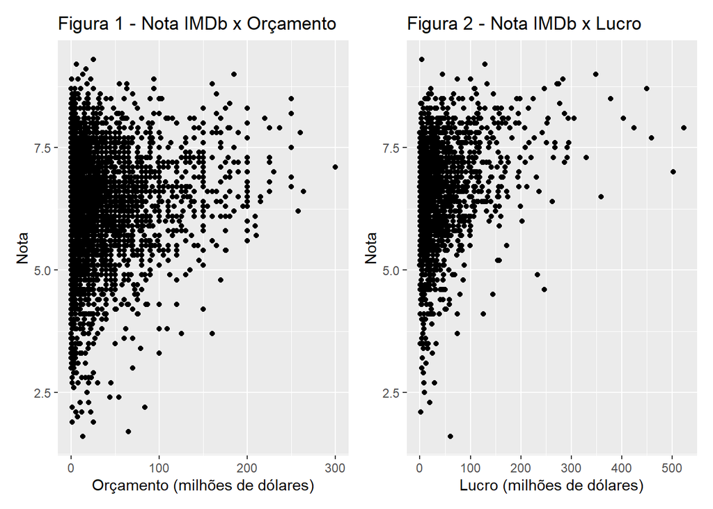

Como queremos encontrar um equílibrio entre orçamento, lucro e popularidade, seguimos analisando e filtrando a base.

## Filmes Lucrativos

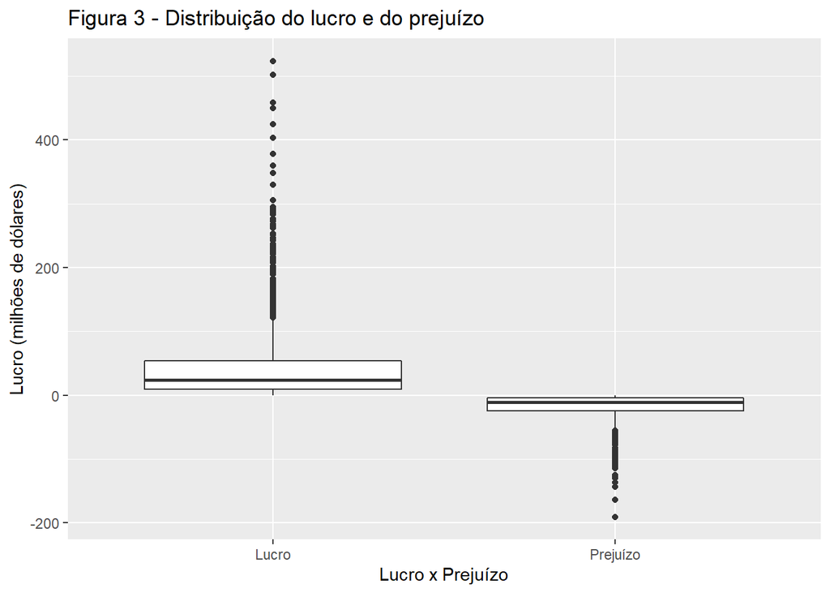

Como o objetivo é produzir um filme lucrativo, vamos analisar especificamente algumas características dos filmes que estão entre os 25% que mais lucraram (lucro a partir de $30.127.620 de dólares) e que tiveram nota IMDn maior ou igual a 8.

## Orçamento dos 25% mais lucrativos

No que tange ao orçamento desses filmes, nota-se que o gasto mínimo para estar entre os 25% dos filmes mais lucrativos foi de $806.947 e o máximo foi de $250.000.000 de dólares. A média do orçamento dos 25% dos filmes mais lucrativos foi de $68.137.080,de dólares.

Em outros termos, tendo em vista um lucro elevado, é interessante avaliar a possibilidade de investimento entre $806.947 e $250.000.000 de dólares.

| País | Média | Mínimo | Máximo |
| --- | --- | --- | --- |
| USA | $68,137,080 | $806,947 | $250,000,000 |

## Diretores Populares

Dentre os diretores que dirigiram filmes lucrativos e com nota IMDb maior ou igual a 8, destacam-se Steven Spielberg com 5 filmes; Quentin Tarantino e Christopher Nolan com 4 filmes cada e Pete Docter, Francis Ford Copola e Clint Eastwood com 3 filmes cada. A figura 4 elenca todos diretores que produziram pelo menos 2 filmes (na condição de lucro acima de $301.276.20,00 e nota IMDb maior ou igual a 8.0).

[figure not shown]

As tabelas abaixo indicam os 5 diretores que obtiveram a maior média de nota IMDb e maior média de lucro, respectivamente:

| Posição | Diretor | Nota_Media |
| --- | --- | --- |
| 1 | Francis Ford Coppola | 8.90 |
| 2 | Peter Jackson | 8.80 |
| 3 | Christopher Nolan | 8.65 |
| 4 | Robert Zemeckis | 8.65 |
| 5 | Steven Spielberg | 8.48 |

| Posição | Diretor | Lucro_Medio |
| --- | --- | --- |
| 1 | Peter Jackson | 264749075 |
| 2 | Robert Zemeckis | 233150479 |
| 3 | Christopher Nolan | 183589832 |
| 4 | Steven Spielberg | 177503386 |
| 5 | Andrew Stanton | 165322880 |

Nota-se que 4 diretores se destacam em ambas as listas: Peter Jackson, Christopher Nolan, Steven Spielberg e Robert Zemeckis. Assim, estes 4 diretores se apresentam como sucessos de bilheteria (em termos de retorno financeiro e avaliação do público).

Nota: nas duas listas foram desconsiderados os diretores George Roy Hill e Milos Forman, falecidos em 2002 e 2018, respectivamente.

## Atores Populares

Com relação aos atores principais, que atuaram em filmes com notas IMDb e lucros elevados, destacam-se: Harrison Ford com 6 filmes, Tom Hanks e Leonardo de Caprio com 5 filmes e Clint EstWood com 3 filmes (foram considerados todos os atores que fizeram 2 ou mais filmes com nota IMDb maior ou igual 8 e lucro acima de $301.276.20).

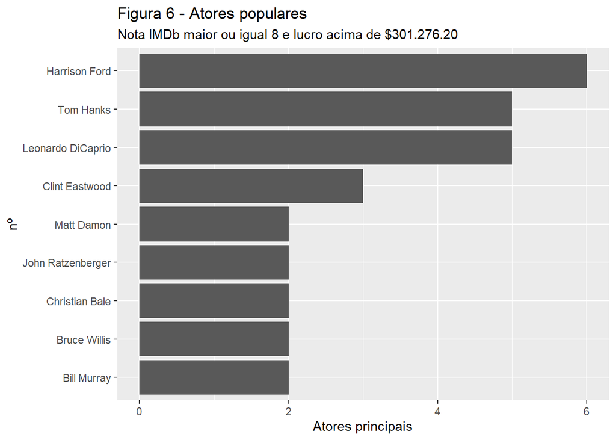

## Faixa Etária

Observa-se que a maioria dos filmes produzidos com nota IMDb maior ou igual 8 e lucro acima de $301.276.20 têm faixa etária a partir de 13 ou 18 anos. A faixa etária a partir de 13 anos é a que possui mais propabilidade de se obter lucros mais elevados, segundo a figura abaixo.

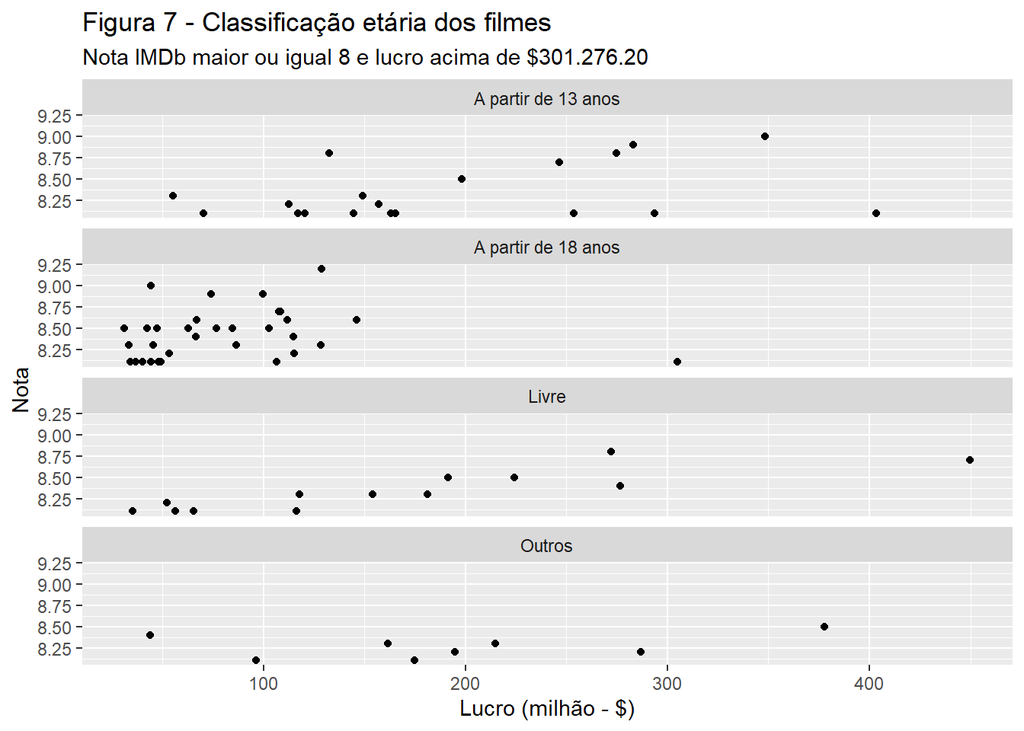

## Duração Média dos filmes

A maioria dos filmes produzidos com nota IMDb maior ou igual 8 e lucro acima de $301.276.20 tem entre 2 e 3 horas de duração.

[figure not shown]

## Considerações Finais

Por fim, a análise da base de dados IMDB com amostra de filmes lançados entre 1969 e 2015 demonstrou que:

- Filmes que ficaram entre os 25% mais lucrativos tiveram orçamento entre $806.947 e $250.000.000 de dólares.
- 4 diretores se destacam em termos de retorno financeiro e nota IMDb: Peter Jackson, Christopher Nolan, Steven Spielberg e Robert Zemeckis
- Os atores mais populares e que participaram de filmes com excelente retorno financeiro são: Harrison Ford, Tom Hanks, Leonardo de Caprio e Clint EstWood.
- As faixas etárias mais populares de filmes lucrativos e com nota IMDb elevevada são a partir de 13 e a partir de 18 anos
- Os filmes têm entre 2 e 3 horas de duração.